# Monte Carlo Simulation

Yves Beutler

02 Juni 2018

## Introduction

This document shows the Monte Carlo simulation for the stock values of famous international companies.

## Prerequisites

To run this simulation you need to install `quantmod` with the following command: `install.packages("quantmod")`. You also need to install `fOptions` for the theoretical black-scholes pricing.

### Importing stock data

We fetch the stock data from the following international companies:

- ABB (electronics)
- UBS (finances)
- Novartis (pharmaceutical)

I use the quantmod library to fetch the data from the year 2017:

```r
getSymbols(companies, src="yahoo", from="2017-01-01", to="2017-12-31")
```

```
## [1] "ABB" "UBS" "NVS"
```

### ABB

These are the ABB stock values of the last year (2017):

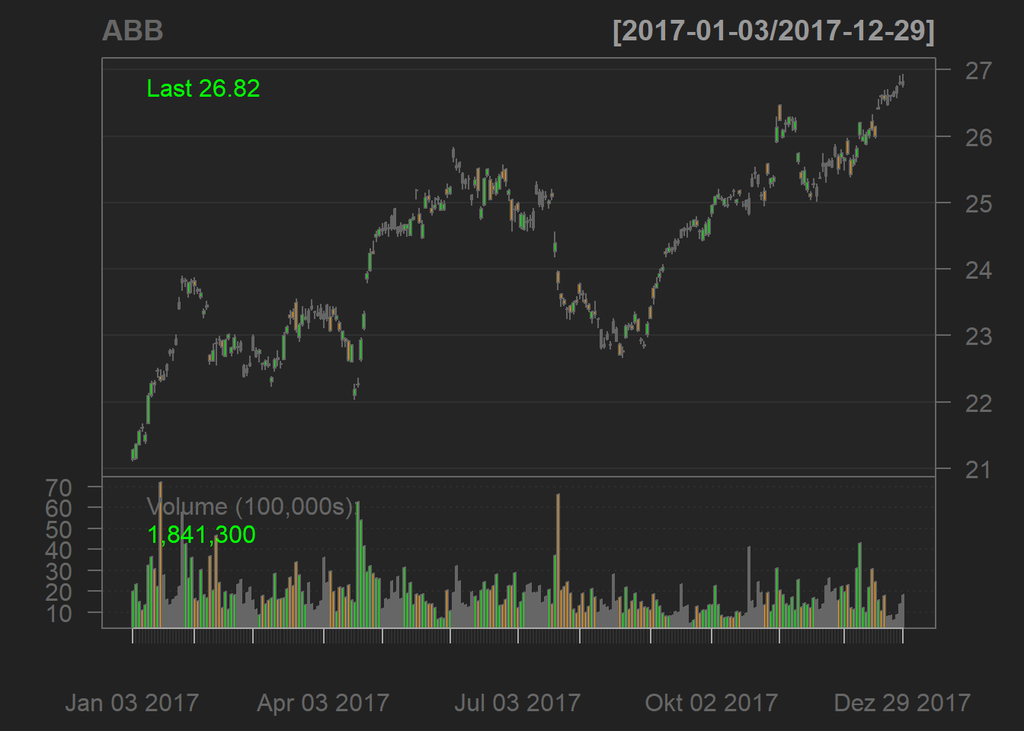

```r
chartSeries(ABB)
```

#### Geometric Brownian Motion (GBM)

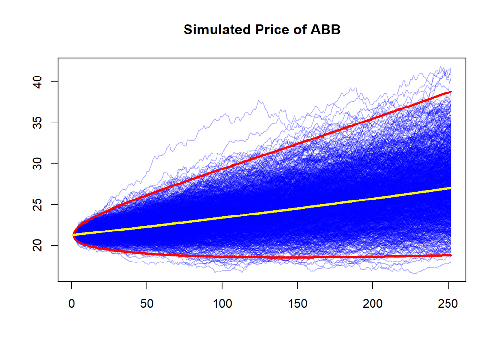

#### Simulation Distribution

We want to check that our values match with the lognormal distribution for the according companies.

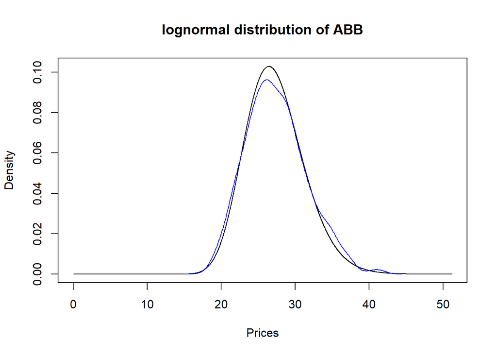

#### Black-Scholes Option Prices

I used the following values:

- Stock price: 21.14$
- Interest: 5%
- Time: 3 Months
- Strike: 23$ (call), 19$ (put)

```r
stock = as.numeric(Op(ABB)[1])
interest = 0.05
strike = 23
bsCall = GBSOption("c", stock, strike, 1/4, interest, interest, sigmaPeak)
cat("estimated Call Price: ",bsCall@price)
```

```
## estimated Call Price:  0.1347675
```

```r
strike = 19
bsPut = GBSOption("p", stock, strike, 1/4, interest, interest, sigmaPeak)
cat("estimated Put Price: ",bsPut@price)
```

```
## estimated Put Price:  0.03021871
```

### UBS

These are the UBS stock values of the last year (2017):

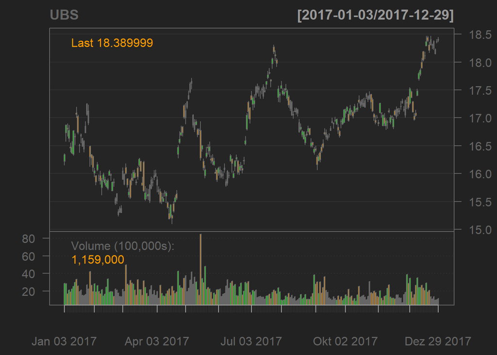

```r
chartSeries(UBS)
```

#### Geometric Brownian Motion (GBM)

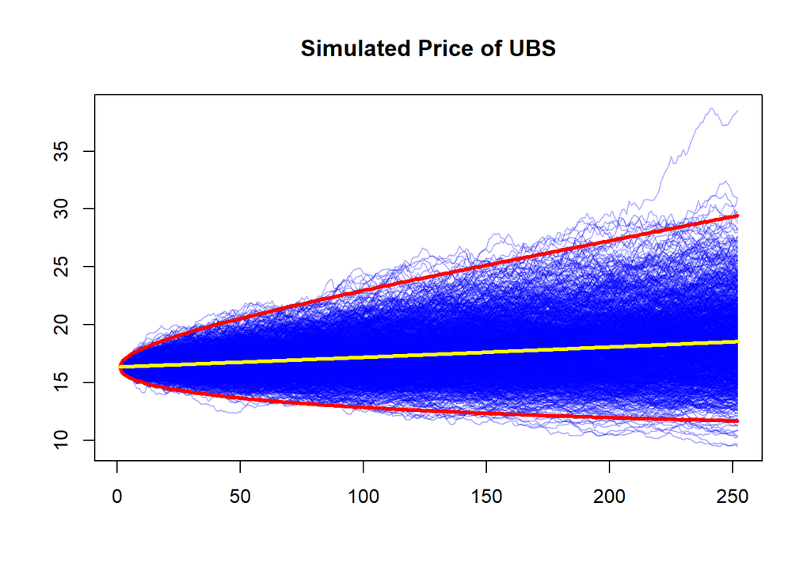

#### Simulation Distribution

We want to check that our values match with the lognormal distribution for the according companies.

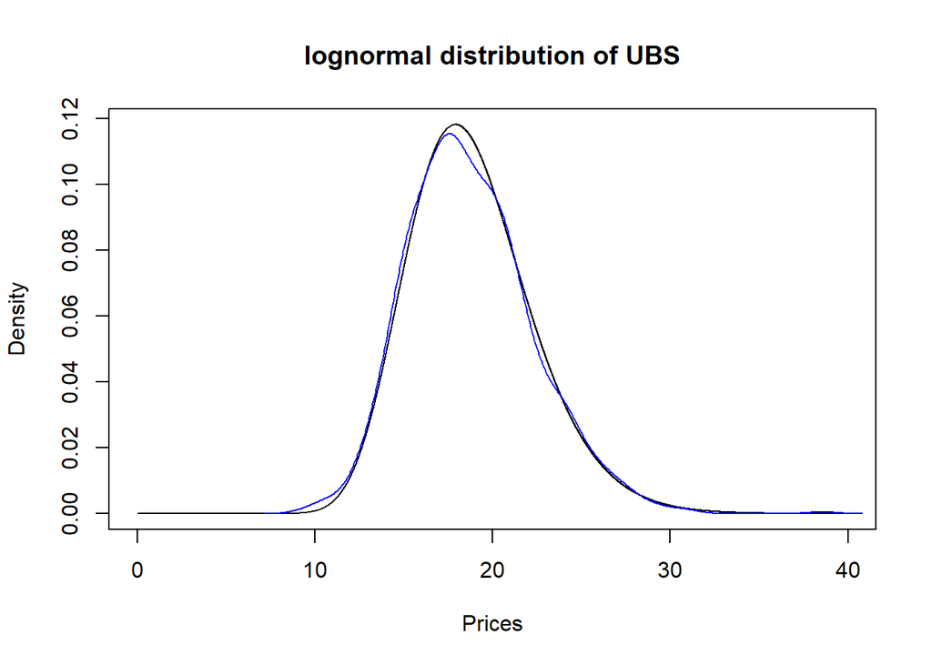

#### Black-Scholes Option Prices

I used the following values:

- Stock price: 16.22$
- Interest: 5%
- Time: 3 Months
- Strike: 18$ (call), 15$ (put)

```r
stock = as.numeric(Op(UBS)[1])
interest = 0.05
strike = 18
bsCall = GBSOption("c", stock, strike, 1/4, interest, interest, sigmaPeak)
cat("estimated Call Price: ",bsCall@price)
```

```
## estimated Call Price:  0.1333171
```

```r
strike = 15
bsPut = GBSOption("p", stock, strike, 1/4, interest, interest, sigmaPeak)
cat("estimated Put Price: ",bsPut@price)
```

```
## estimated Put Price:  0.1240447
```

### Novartis

These are the Novartis stock values of the last year (2017):

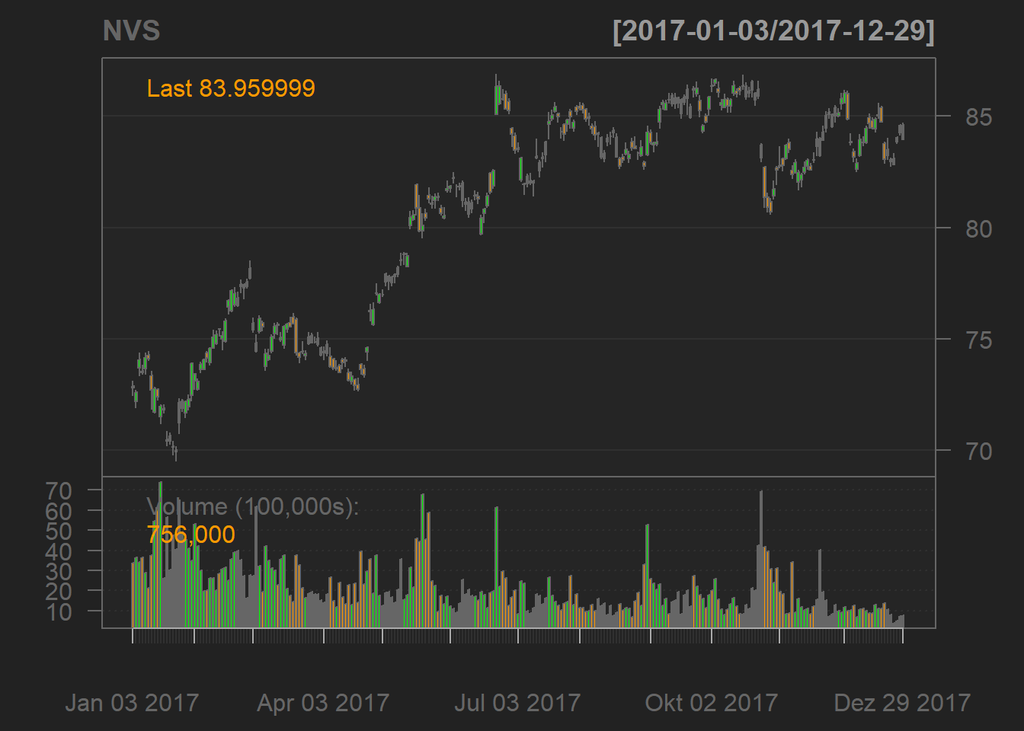

```r
chartSeries(NVS)
```

#### Geometric Brownian Motion (GBM)

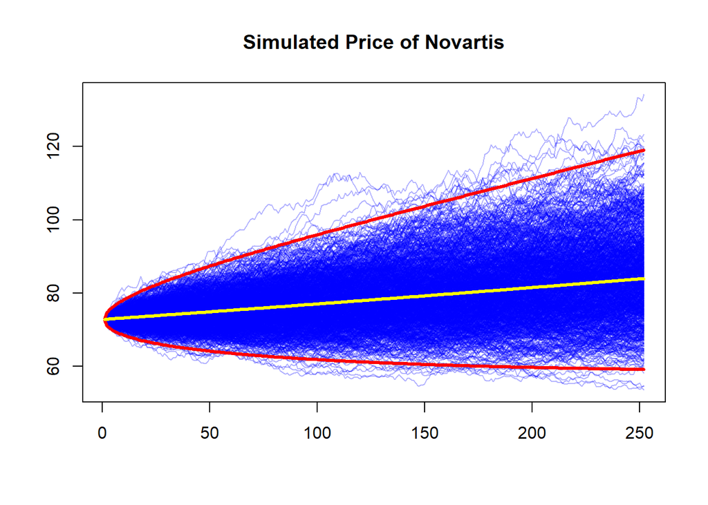

#### Simulation Distribution

We want to check that our values match with the lognormal distribution for the according companies.

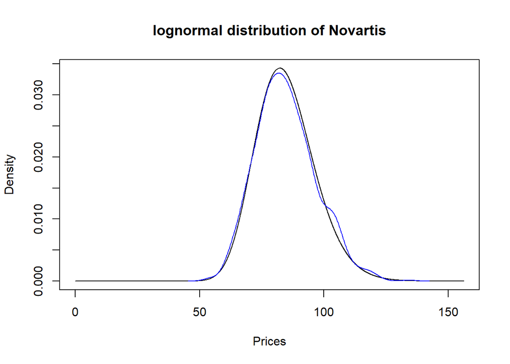

#### Black-Scholes Option Prices

I used the following values:

- Stock price: 72.89$
- Interest: 5%
- Time: 3 Months
- Strike: 80$ (call), 65$ (put)

```r
stock = as.numeric(Op(NVS)[1])
interest = 0.05
strike = 80
bsCall = GBSOption("c", stock, strike, 1/4, interest, interest, sigmaPeak)
cat("estimated Call Price: ",bsCall@price)
```

```
## estimated Call Price:  0.3282976
```

```r
strike = 65
bsPut = GBSOption("p", stock, strike, 1/4, interest, interest, sigmaPeak)
cat("estimated Put Price: ",bsPut@price)
```

```
## estimated Put Price:  0.06550017
```